# Project: Investigate a Dataset - Movie Database (TMDb)

- Introduction
- Data Wrangling
- Exploratory Data Analysis
- Questions
- Question 1
- Question 2
- Question 3
- Question 4
- Question 5
- Conclusions

## Introduction

### Dataset Description

This dataset contains over 10k entries from TMDb related to films made from 1960-2015. The dataset contains a large number of irregular characters in columns like “production_companies” and “cast” that have been used to replace special characters like accents. Unfortunately, without having the correct names, I won’t be able to utilize some of the information contained in the data. There is a large number of missing values in both 'budget_adj' and 'revenue_adj', but I'll work with the information that is available.

### Question(s) for Analysis. What makes a "good" film?

**Questions**

**Who are the most prolific actors**

**Which Actor(s) have driven the highest revenue?**

**Is there a correlation between big budget and high revenue?**

**Are "Popular" films more profitable?**

**Which genre(s) is most popular/profitable?**

## Data Wrangling

This dataset contains a large number of irregular characters which may or may not impact the analysis later

```python
# Importing the packages

import pandas as pd
import numpy as np
import operator
import matplotlib.pylab as plt
import seaborn as sns
import warnings
warnings.simplefilter(action='ignore', category=FutureWarning)
plt.rcParams['font.family'] = 'sans-serif'
```

```python
# Importing the data set and performing some initial inspections

data = pd.read_csv('tmdb-movies.csv', encoding='ISO-8859-1')
for i,v in enumerate(data.columns):
    print(i,v)
```

```
0 id
1 imdb_id
2 popularity
3 budget
4 revenue
5 original_title
6 cast
7 homepage
8 director
9 tagline
10 keywords
11 overview
12 runtime
13 genres
14 production_companies
15 release_date
16 vote_count
17 vote_average
18 release_year
19 budget_adj
20 revenue_adj
```

```python
# For my analysis I'll work with the columns listed here:

df = data[['id', 'popularity','original_title','cast','director','runtime','genres',
           'production_companies', 'vote_count',
           'vote_average', 'release_year', 'budget_adj','revenue_adj']].copy()


# Looking at a snapshot of the dataframe
df.head()
```

|  | id | popularity | original_title | cast | director | runtime | genres | production_companies | vote_count | vote_average | release_year | budget_adj | revenue_adj |
| --- | --- | --- | --- | --- | --- | --- | --- | --- | --- | --- | --- | --- | --- |
| 0 | 280996 | 3.93 | Mr. Holmes | Ian McKellen\|Milo Parker\|Laura Linney\|Hattie M... | Bill Condon | 103 | Mystery\|Drama | BBC Films\|See-Saw Films\|FilmNation Entertainme... | 425 | 6.40 | 2015 | 0.00 | 27006774.88 |
| 1 | 339527 | 3.36 | Solace | Abbie Cornish\|Jeffrey Dean Morgan\|Colin Farrel... | Afonso Poyart | 101 | Crime\|Drama\|Mystery | Eden Rock Media\|FilmNation Entertainment\|Flynn... | 474 | 6.20 | 2015 | 0.00 | 20566197.19 |
| 2 | 284289 | 2.27 | Beyond the Reach | Michael Douglas\|Jeremy Irvine\|Hanna Mangan Law... | Jean-Baptiste LÃ©onetti | 95 | Thriller | Furthur Films | 81 | 5.50 | 2015 | 0.00 | 42223.38 |
| 3 | 347096 | 2.17 | Mythica: The Darkspore | Melanie Stone\|Kevin Sorbo\|Adam Johnson\|Jake St... | Anne K. Black | 108 | Action\|Adventure\|Fantasy | Arrowstorm Entertainment | 27 | 5.10 | 2015 | 0.00 | 0.00 |
| 4 | 308369 | 2.14 | Me and Earl and the Dying Girl | Thomas Mann\|RJ Cyler\|Olivia Cooke\|Connie Britt... | Alfonso Gomez-Rejon | 105 | Comedy\|Drama | Indian Paintbrush | 569 | 7.70 | 2015 | 0.00 | 0.00 |

**These next two cells will look at the state of the data, missing values, data types, outliers etc.**

```python
df.info()
```

```
<class 'pandas.core.frame.DataFrame'>
RangeIndex: 10866 entries, 0 to 10865
Data columns (total 13 columns):
 #   Column                Non-Null Count  Dtype
---  ------                --------------  -----
 0   id                    10866 non-null  int64
 1   popularity            10866 non-null  float64
 2   original_title        10866 non-null  object
 3   cast                  10790 non-null  object
 4   director              10822 non-null  object
 5   runtime               10866 non-null  int64
 6   genres                10843 non-null  object
 7   production_companies  9836 non-null   object
 8   vote_count            10866 non-null  int64
 9   vote_average          10866 non-null  float64
 10  release_year          10866 non-null  int64
 11  budget_adj            10866 non-null  float64
 12  revenue_adj           10866 non-null  float64
dtypes: float64(4), int64(4), object(5)
memory usage: 1.1+ MB
```

**We can already see that there are some missing values from this data set, however, with further investigation, these missing values may not impact my analysis**

```python
df.describe()
```

|  | id | popularity | runtime | vote_count | vote_average | release_year | budget_adj | revenue_adj |
| --- | --- | --- | --- | --- | --- | --- | --- | --- |
| count | 10866.00 | 10866.00 | 10866.00 | 10866.00 | 10866.00 | 10866.00 | 10866.00 | 10866.00 |
| mean | 66064.18 | 0.65 | 102.07 | 217.39 | 5.97 | 2001.32 | 17551039.82 | 51228798.23 |
| std | 92130.14 | 1.00 | 31.38 | 575.62 | 0.94 | 12.81 | 34306155.72 | 143885112.60 |
| min | 5.00 | 0.00 | 0.00 | 10.00 | 1.50 | 1960.00 | 0.00 | 0.00 |
| 25% | 10596.25 | 0.21 | 90.00 | 17.00 | 5.40 | 1995.00 | 0.00 | 0.00 |
| 50% | 20669.00 | 0.38 | 99.00 | 38.00 | 6.00 | 2006.00 | 0.00 | 0.00 |
| 75% | 75610.00 | 0.71 | 111.00 | 145.75 | 6.60 | 2011.00 | 20853251.08 | 33697095.72 |
| max | 417859.00 | 32.99 | 900.00 | 9767.00 | 9.20 | 2015.00 | 425000000.00 | 2827123750.00 |

**There are some clear errors displayed here in terms of outliers, minimum runtime, adjusted budget/revenue are all 0.00. While this is possible for budget (unless they are "Mirco-Bduget films") and revenue, (possible but unlikely), no film has a runtime of 0.00.**

**And at the other end of the scale, there is a maximum budget amount of over $400mil. While possible, it's worth investigating**

### Data Cleaning

```python
# Removing whitespaces from the columns

df.rename(columns=lambda x: x.strip(), inplace=True)
```

```python
#############################

# Identfiying duplicates

#############################

df[df.duplicated()]
```

|  | id | popularity | original_title | cast | director | runtime | genres | production_companies | vote_count | vote_average | release_year | budget_adj | revenue_adj |
| --- | --- | --- | --- | --- | --- | --- | --- | --- | --- | --- | --- | --- | --- |
| 8736 | 42194 | 0.60 | TEKKEN | Jon Foo\|Kelly Overton\|Cary-Hiroyuki Tagawa\|Ian... | Dwight H. Little | 92 | Crime\|Drama\|Action\|Thriller\|Science Fiction | Namco\|Light Song Films | 110 | 5.00 | 2010 | 30000000.00 | 967000.00 |

```python
#####################################

# Removing the duplicates

#####################################

df.drop_duplicates(inplace=True)
df[df.duplicated()]
```

|  | id | popularity | original_title | cast | director | runtime | genres | production_companies | vote_count | vote_average | release_year | budget_adj | revenue_adj |
| --- | --- | --- | --- | --- | --- | --- | --- | --- | --- | --- | --- | --- | --- |

```python
# Inspecting the budget outliers

# Total number of rows/columns
print(df.shape)

# Number of rows that have a budget of 0.00
print(df[df['budget_adj'] <=0]['budget_adj'].count())

# Number of rows that have a revenue of 0.00
print(df[df['revenue_adj'] <=0]['revenue_adj'].count())

# Number of rows that have a budget over $400 million
print(df[df['budget_adj'] >=400000000]['budget_adj'].count())
```

```
(10865, 13)
5696
6016
1
```

**In dataframe of 10866 rows over 5000 of them have a budget of 0.00, 6016 of them have a revenue amount of 0.00 and one film has a budget of over $400mil.**

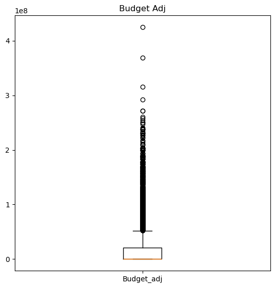

```
''
```

```python
# Plotting the adjusted budget

budgets = df[['budget_adj']]

fig = plt.figure(figsize=(5,5))
axl = fig.add_axes([0,0,1,1])
axl.boxplot(budgets, labels=['Budget_adj'])
plt.title('Budget Adj')
plt.show()
;
```

**This budget error could be due to a number of factors, the information e.g. may not have been recorded/available For this analysis I’ll concentrate on the top ‘n’ amounts and exclude the errors.**

**However I will investigate the one record that has the $400mil budget.**

```python
################################

# Identfying the high budget outliers

################################

df[df['budget_adj'] >=400000000]
```

|  | id | popularity | original_title | cast | director | runtime | genres | production_companies | vote_count | vote_average | release_year | budget_adj | revenue_adj |
| --- | --- | --- | --- | --- | --- | --- | --- | --- | --- | --- | --- | --- | --- |
| 10865 | 46528 | 0.25 | The Warrior's Way | Kate Bosworth\|Jang Dong-gun\|Geoffrey Rush\|Dann... | Sngmoo Lee | 100 | Adventure\|Fantasy\|Action\|Western\|Thriller | Boram Entertainment Inc. | 74 | 6.40 | 2010 | 425000000.00 | 11087569.00 |

**Upon further investigation, I found that this film "The Warriors Way" actually had declared budget of 42 million dollars as opposed to 425 million More information can be found on Box Office Mojo: https://www.boxofficemojo.com/release/rl444106241/**

```python
###############################################

# This will amend the budget information error

###############################################

clean = { 425000000.00 : 42000000.00}
df.replace({'budget_adj':clean}, inplace=True)
df.describe()
```

|  | id | popularity | runtime | vote_count | vote_average | release_year | budget_adj | revenue_adj |
| --- | --- | --- | --- | --- | --- | --- | --- | --- |
| count | 10865.00 | 10865.00 | 10865.00 | 10865.00 | 10865.00 | 10865.00 | 10865.00 | 10865.00 |
| mean | 66066.37 | 0.65 | 102.07 | 217.40 | 5.98 | 2001.32 | 17514643.23 | 51233424.26 |
| std | 92134.09 | 1.00 | 31.38 | 575.64 | 0.94 | 12.81 | 34084878.04 | 143890926.46 |
| min | 5.00 | 0.00 | 0.00 | 10.00 | 1.50 | 1960.00 | 0.00 | 0.00 |
| 25% | 10596.00 | 0.21 | 90.00 | 17.00 | 5.40 | 1995.00 | 0.00 | 0.00 |
| 50% | 20662.00 | 0.38 | 99.00 | 38.00 | 6.00 | 2006.00 | 0.00 | 0.00 |
| 75% | 75612.00 | 0.71 | 111.00 | 146.00 | 6.60 | 2011.00 | 20853251.08 | 33701729.01 |
| max | 417859.00 | 32.99 | 900.00 | 9767.00 | 9.20 | 2015.00 | 368371256.20 | 2827123750.00 |

```python
df[df['budget_adj'] >= 400000000.00]
```

|  | id | popularity | original_title | cast | director | runtime | genres | production_companies | vote_count | vote_average | release_year | budget_adj | revenue_adj |
| --- | --- | --- | --- | --- | --- | --- | --- | --- | --- | --- | --- | --- | --- |

**The budget has now been corrected**

#### Analysing the runtimes

```python
df.runtime.describe()
```

```
count   10865.00
mean      102.07
std        31.38
min         0.00
25%        90.00
50%        99.00
75%       111.00
max       900.00
Name: runtime, dtype: float64
```

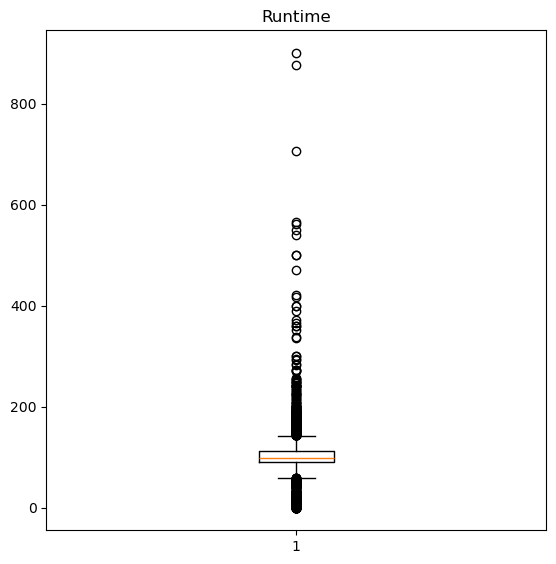

```
''
```

```python
fig = plt.figure(figsize=(5,5))
axl = fig.add_axes([0,0,1,1])
axl.boxplot(df.runtime)
plt.title('Runtime')
plt.show()
;
```

**There are a number of outliers shown here that I will look into.**

```python
df[df.runtime == df.runtime.max()]
```

|  | id | popularity | original_title | cast | director | runtime | genres | production_companies | vote_count | vote_average | release_year | budget_adj | revenue_adj |
| --- | --- | --- | --- | --- | --- | --- | --- | --- | --- | --- | --- | --- | --- |
| 2126 | 125336 | 0.01 | The Story of Film: An Odyssey | Mark Cousins\|Jean-Michel Frodon\|Cari Beauchamp... | Mark Cousins | 900 | Documentary | NaN | 14 | 9.20 | 2011 | 0.00 | 0.00 |

**Further investigation shows that the runtime is actually correct: https://en.wikipedia.org/wiki/The_Story_of_Film:_An_Odyssey "The Story of Film: An Odyssey" is in fact over 900 minutes long.**

**The time, budgets and revenue have been cleaned as much as, reasonably, possible.**

### Function repositiory

**As mentioned earlier, there are some irregular characters and a lot of missing values and so I will only work with the top 'n'**

**Below are some functions that will elimnate the need for rep**

```python
###########################################

# This function will return a dataframe with the top 10 monetary values sorted by descending order.

###########################################


def get_top_10(dataframe, display_column, sort_column, n=10, ascending=False):
    """
    Function to return the top 10 rows of a dataframe based on a sort column.

    Parameters:
    dataframe: The input dataframe.
    display_column: The column to display in the output.
    sort_column (str): The column to sort by.
    n (int): Number of top rows to return. Default is 10.
    ascending (boolean): Sort order. False for descending (default), True for ascending.

    Returns:
    pd.DataFrame: DataFrame with the top n rows.
    """
    # Sort the dataframe based on the sort column
    sorted_df = dataframe.sort_values(by=sort_column, ascending=ascending)

    # Select the top n rows
    top_n_df = sorted_df.head(n)

    # Return only the relevant column
    return top_n_df[[display_column, sort_column]]

;


###########################################

# This function will return a dataframe with the top 10 voting average/popularity values sorted by ascending/descending order.

###########################################

def votes_and_pop(dataframe, display_columns, sort_column, n=10, ascending=False):
    """
    Function to return the top 10 rows of a dataframe and on a sort column.

    Parameters:
    dataframe: The input dataframe.
    display_columns (list): The columns to display in the output, title, vote average etc.
    sort_column: The column to sort by.
    n (int): Number of top rows to return. Default is 10.
    ascending (boolean): Sort order. False for descending (default), True for ascending.

    Returns:
    DataFrame with the top n rows.
    """
    if ascending:
        top_n_df = dataframe.nsmallest(n, sort_column)
    else:
        top_n_df = dataframe.nlargest(n, sort_column)

    return top_n_df[display_columns]

;


###########################################

# This function will return a dataframe with the top 20 "lead" actors (defined by being listed first) who have
# appeared in the most films.

###########################################

def get_most_prolific_actors(df):
    """
    Reads the movie data and returns the top 20 most prolific actors
    based on the number of appearances.

    Parameters:
    file_path (str): The path to the .csv file.

    Returns:
    DataFrame: A DataFrame containing the top 20 most prolific actors by the number of appearances.
    """

    # Filter out rows where 'cast' is not null
    cast_list = df[df.cast.notnull()].copy()

    # Split the 'cast' column to create a list of actors names
    cast_list['actors'] = cast_list.cast.str.split("|").copy()

    # Extract the lead actor(s) from the list of actors, lead is based on the first name listed
    cast_list['lead_actor'] = cast_list['actors'].str[0].copy()

    # Create a DataFrame with columns 'lead_actor', 'id', 'popularity', 'revenue_adj'
    appearances = cast_list[['lead_actor', 'id', 'popularity', 'revenue_adj']]

    # Group by 'lead_actor' to count the top 20 number of appearances
    most_prolific = appearances.groupby('lead_actor', as_index=False)['id'].count().sort_values(by='id',
                                                                    ascending=False).nlargest(20, 'id')

    # Strip whitespace from 'lead_actor' column
    most_prolific['lead_actor'] = most_prolific['lead_actor'].str.strip()

    return most_prolific

;
```

```
''
```

## Exploratory Data Analysis

### Research Question: What makes a good film?

**Film production over the decades**

[figure not shown]

```
''
```

```python
# Setting the theme
sns.set_theme(style="whitegrid", palette="pastel")

# Caluclating the number of productions per decade
no_of_films = df[['release_year','id']].groupby(['release_year'],as_index=False).count().sort_values(by= ['release_year'],
                                                    ascending=False)

# Creating the plot

fig, ax = plt.subplots()
ax.plot(no_of_films['release_year'], no_of_films['id'])
plt.title('Number of films per Decade')
plt.xlabel('Decades')
plt.ylabel('No. of Films')

plt.show()
;
```

**Over the decades it's very clear that there has been an increase in demand for films. We'll have a deeper look into other aspects of this data.**

## Questions

### Question 1: Who are the most prolific actors

**The next two figures will look at the most appearences per actor, who is the most prolific actor?**

**And does the "Moviestar" exist? Does the number of films impact the box office in a positive way?**

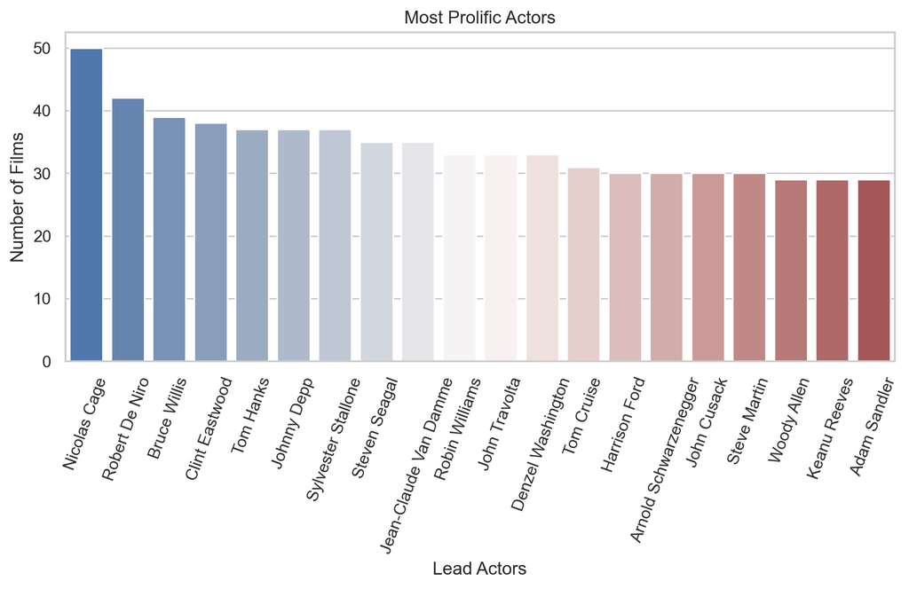

```python
most_prolific_actors = get_most_prolific_actors(df)


# Creating the plot
plt.figure(figsize=(10, 4), dpi=200)
sns.barplot(x='lead_actor', y='id', data=most_prolific_actors, palette='vlag')
plt.ylabel('Number of Films')
plt.xlabel('Lead Actors')
plt.xticks(rotation=70)
plt.title('Most Prolific Actors')
plt.show()
```

**The actor Nicolas Cage has appeared in more films as the lead, than any other actor in the data with 50 appearences.**

**However, thanks to further invesitgation, he is not the most prolific Hollywood actor, that title would go to Irving Bacon who has 526 acting credits. (not included in this dataset)**

### Question 2: Which Actor(s) have driven the highest revenue?

[figure not shown]

```
''
```

```python
# Filter out rows where 'cast' is not null
cast_list = df[df.cast.notnull()].copy()

# Split the 'cast' column to create a list of actors
cast_list['actors'] = cast_list.cast.str.split("|").copy()

# Extract the lead actor from the list of actors
cast_list['lead_actor'] = cast_list['actors'].str[0].copy()

# Create a DataFrame with columns 'lead_actor', 'id', 'popularity', 'revenue_adj'
appearances = cast_list[['lead_actor', 'id', 'popularity', 'revenue_adj']]

# Making the revenue values easier to read
pd.options.display.float_format = '{:.2f}'.format

# Rounding up the revenue values
appearances.loc[:, 'revenue_adj'] = np.round(appearances['revenue_adj'],0)

# Dropping 0 values
appearances = appearances[appearances.revenue_adj > 0]

movie_stars = appearances[['lead_actor','revenue_adj']].groupby(['lead_actor'],
                                                    as_index=False).sum().sort_values(by= ['revenue_adj'],
                                                    ascending=False).nlargest(20, 'revenue_adj')


movie_stars.loc[:, 'revenue_adj'] = round(movie_stars.revenue_adj/1000000,2)


plt.figure(figsize=(10,4),dpi=200)
sns.barplot(x='lead_actor', y='revenue_adj',data = movie_stars,palette='vlag')
plt.xticks(rotation=70)
plt.title("Top 20 'Lead Actors' based on Adjusted Revenue")
plt.ylabel('Total Adjusted Revenue in $Bil')
plt.xlabel("Lead Actor")
plt.show()
;
```

**While Nicolas Cage has appeared in more films, it's Tom Cruise who has appeared in more successful, from a box office perspective, films.**

```python
# Pullting the cast list from the 10 highest box office movies
top10_films_and_actors = df.nlargest(10, 'revenue_adj')[['original_title', 'cast']]
top10_films_and_actors['cast'] = top10_films_and_actors.cast.str.split("|").copy()
top10_films_and_actors
```

|  | original_title | cast |
| --- | --- | --- |
| 10853 | Avatar | [Sam Worthington, Zoe Saldana, Sigourney Weave... |
| 9228 | Star Wars | [Mark Hamill, Harrison Ford, Carrie Fisher, Pe... |
| 10861 | Titanic | [Kate Winslet, Leonardo DiCaprio, Frances Fish... |
| 9224 | The Exorcist | [Linda Blair, Max von Sydow, Ellen Burstyn, Ja... |
| 8651 | Jaws | [Roy Scheider, Robert Shaw, Richard Dreyfuss, ... |
| 10802 | Star Wars: The Force Awakens | [Harrison Ford, Mark Hamill, Carrie Fisher, Ad... |
| 8345 | E.T. the Extra-Terrestrial | [Henry Thomas, Drew Barrymore, Robert MacNaugh... |
| 8705 | One Hundred and One Dalmatians | [Rod Taylor, J. Pat O'Malley, Betty Lou Gerson... |
| 10833 | The Avengers | [Robert Downey Jr., Chris Evans, Mark Ruffalo,... |
| 9499 | The Empire Strikes Back | [Mark Hamill, Harrison Ford, Carrie Fisher, Bi... |

**However while the cumulative total of Tom Cruise's films has generated more box office returns, he has not appeared in any of the top 10 highest box office films.**

### Question 3: Is there a correlation between big budget films and box office returns (high revenue)?

#### Top 10 big box office returns along with their budgets

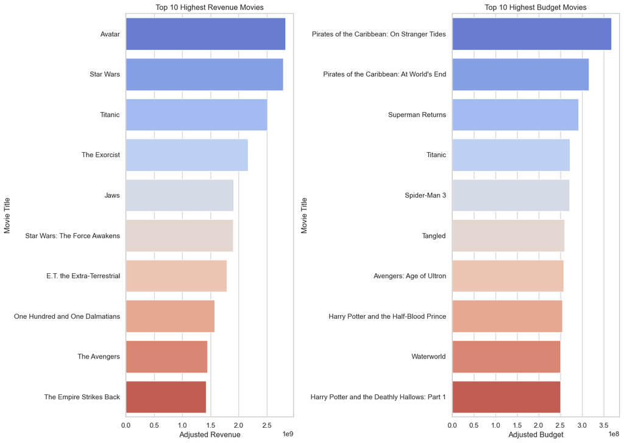

```python
# Pulling the top 10 highest revenue_adj and budget_adj movies
top_10_revenue = get_top_10(df,'original_title','revenue_adj',ascending=False)
top_10_budget = get_top_10(df,'original_title','budget_adj',ascending=False)

# Plotting
plt.figure(figsize=(14, 10))

# Creating the plot for top 10 highest revenue_adj movies
plt.subplot(1, 2, 1)
sns.barplot(data=top_10_revenue, y='original_title', x='revenue_adj', palette='coolwarm')
plt.xlabel('Adjusted Revenue')
plt.ylabel('Movie Title')
plt.title('Top 10 Highest Revenue Movies')

# Creating the plot for top 10 highest budget_adj movies
plt.subplot(1, 2, 2)
sns.barplot(data=top_10_budget, y='original_title', x='budget_adj', palette='coolwarm')
plt.xlabel('Adjusted Budget')
plt.ylabel('Movie Title')
plt.title('Top 10 Highest Budget Movies')

plt.tight_layout()
plt.show()
```

**Surprisingly, Avatar doesn't break into the top 10 "Big budget" films and yet it has the highest box office. Similarly, the highest budgeted film "Pirates of the Caribbean On Stranger Tides" doesn't break into the top 10 high revenue films.**

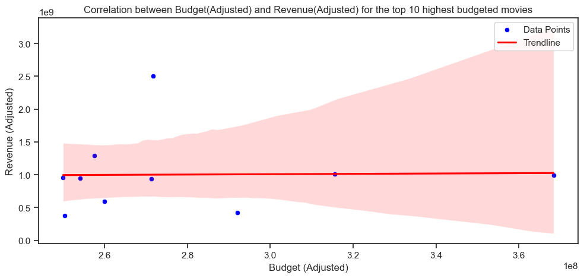

```python
# Get the top 10 highest budget_adj movies
adj_budget = df.nlargest(10, 'budget_adj')

# Plotting
plt.figure(figsize=(10, 5))

# Scatter plot
sns.scatterplot(data=adj_budget, x='budget_adj', y='revenue_adj', color='blue', label='Data Points')

# Trendline
sns.regplot(data=adj_budget, x='budget_adj', y='revenue_adj', scatter=False, color='red', label='Trendline')

# Set the theme and labels
sns.set_theme(style="ticks")
plt.title('Correlation between Budget(Adjusted) and Revenue(Adjusted) for the top 10 highest budgeted movies')
plt.xlabel('Budget (Adjusted)')
plt.ylabel('Revenue (Adjusted)')
plt.legend()
plt.tight_layout()
plt.show()
```

**There are some noticeable outliers shown here, there is a slight correlation between the two variables. However, we cannot say for certainty that a “Big Budget” movie will equate to “High Box Office (Revenue)”, as shown in pervious charts.**

### Question 4: Are "Popular"/"Highly Voted" films more profitable?

**The next few figures will investigate whether or not popularity is correlated with box office (Revenue).**

#### Looking at "Popularity" and "Vote Average"

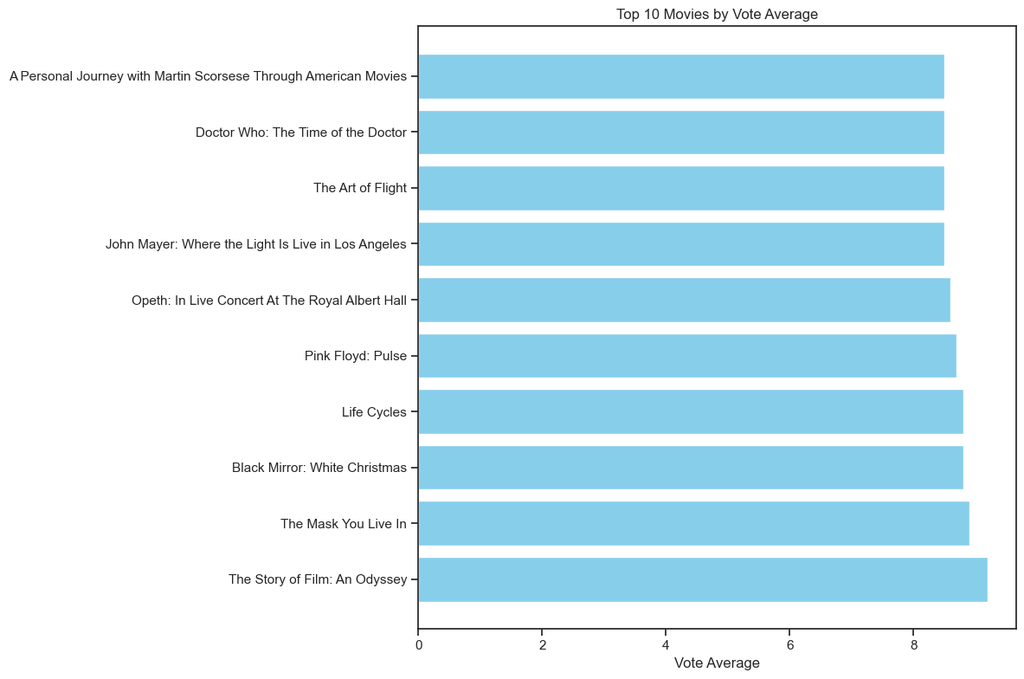

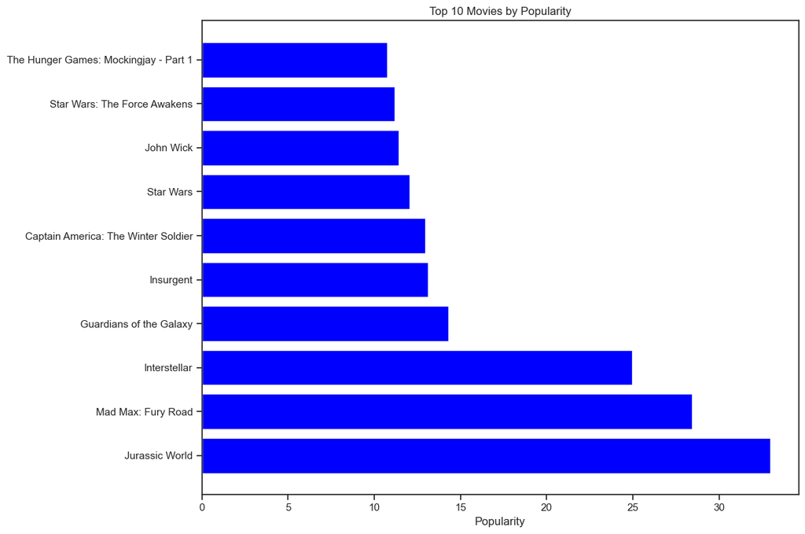

```python
# Getting the top 10 highest vote_average movies
top_10_vote_avg = votes_and_pop(df,['original_title', 'vote_average'], 'vote_average', n=10, ascending=False)

# Get the top 20 highest popularity movies
top_10_popularity = votes_and_pop(df,['original_title', 'popularity'], 'popularity', n=10, ascending=False)

# Plotting the top 20 highest vote_average movies
plt.figure(figsize=(12, 8))
plt.barh(top_10_vote_avg['original_title'], top_10_vote_avg['vote_average'], color='skyblue')
plt.xlabel('Vote Average')
plt.title('Top 10 Movies by Vote Average')
plt.tight_layout()
plt.show()

# Plotting the top 20 highest popularity movies
plt.figure(figsize=(12, 8))
plt.barh(top_10_popularity['original_title'], top_10_popularity['popularity'], color='blue')
plt.xlabel('Popularity')
plt.title('Top 10 Movies by Popularity')
plt.tight_layout()
plt.show()
```

**These graphs show some fascinating insights into the data, as we can see there is no crossover between the two lists.**

**None of the “Most Popular” films appear in the “Most Voted" list**

**Furthermore none of the most voted films appear on the "Top 10 Highest Budget Movies" and only two films from the “Most Popular” list appear in the “Top 10 Highest Box Office” list:**

**Star Wars**

**Star Wars: The Force Awakens**

**Reminder below.**

```python
#Top 10 biggest box office films
top_10_revenue[['original_title','revenue_adj']]
```

|  | original_title | revenue_adj |
| --- | --- | --- |
| 10853 | Avatar | 2827123750.00 |
| 9228 | Star Wars | 2789712242.00 |
| 10861 | Titanic | 2506405735.00 |
| 9224 | The Exorcist | 2167324901.00 |
| 8651 | Jaws | 1907005842.00 |
| 10802 | Star Wars: The Force Awakens | 1902723130.00 |
| 8345 | E.T. the Extra-Terrestrial | 1791694309.00 |
| 8705 | One Hundred and One Dalmatians | 1574814740.00 |
| 10833 | The Avengers | 1443191435.00 |
| 9499 | The Empire Strikes Back | 1424626188.00 |

#### Box Office and Popularity/ Vote Correlation

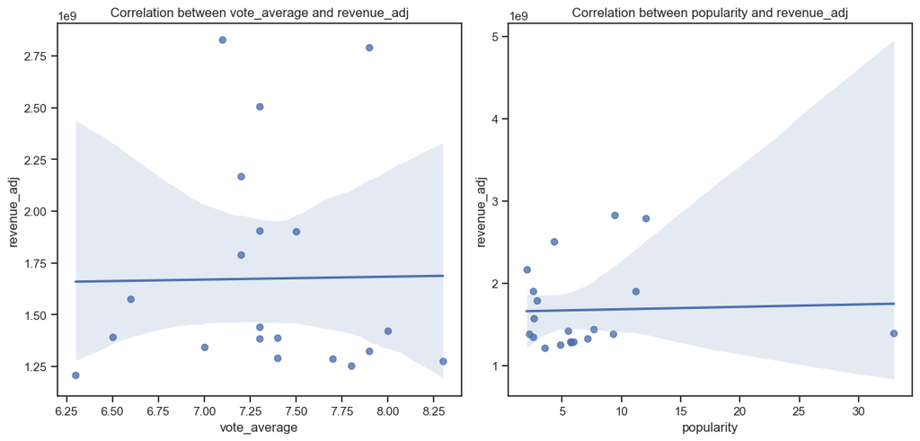

```
''
```

```python
# Setting the style
sns.set_theme(style="ticks")
# Filter the top 20 highest revenue_adj movies
top_revenue_movies = df.nlargest(20, 'revenue_adj').sort_values(by='revenue_adj', ascending=False)

# Creating two separate DataFrames for vote_average vs. revenue_adj and popularity vs. revenue_adj
vote_avg_vs_revenue = top_revenue_movies[['vote_average', 'revenue_adj']]
popularity_vs_revenue = top_revenue_movies[['popularity', 'revenue_adj']]

# Creating side-by-side correlation charts
plt.figure(figsize=(12, 6))

# Plot vote_average vs. revenue_adj
plt.subplot(1, 2, 1)
sns.regplot(data=vote_avg_vs_revenue, x='vote_average', y='revenue_adj')
plt.title('Correlation between vote_average and revenue_adj')

# Plot popularity vs. revenue_adj
plt.subplot(1, 2, 2)
sns.regplot(data=popularity_vs_revenue, x='popularity', y='revenue_adj')
plt.title('Correlation between popularity and revenue_adj')

plt.tight_layout()
plt.show()
;
```

### Question 5: Which genre is most popular?

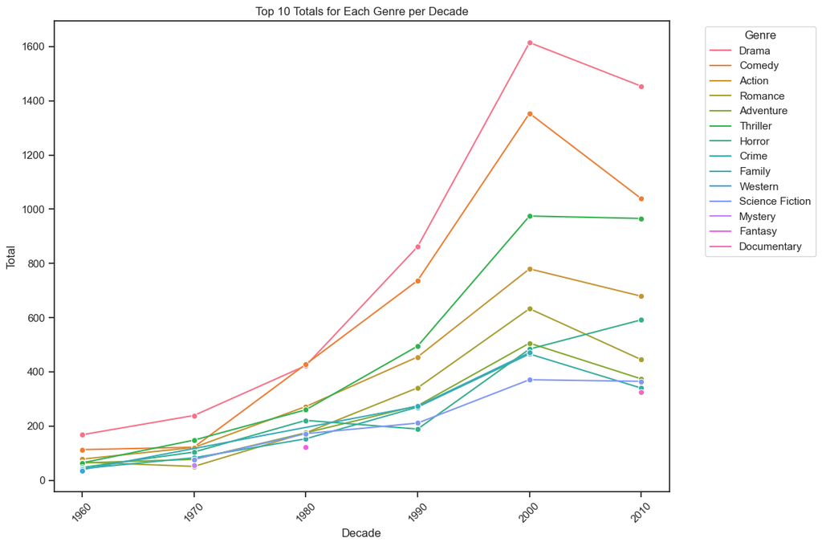

```python
# Select relevant columns
df1 = data[['genres', 'release_year']].copy()

# Dropping rows where "genres" is null
df1 = df1.dropna(subset=["genres"])

# Extracting decade from release_year
df1['decade'] = df1['release_year'] // 10 * 10

# Splitting genres into separate rows
genres_df = df1['genres'].str.split('|', expand=True)
genres_df['decade'] = df1['decade']

# Melt the DataFrame to have a long-form DataFrame
genres_df_melted = pd.melt(genres_df, id_vars='decade', value_name='genre').dropna()

# Grouping by decade and genre, counting the occurrences, and finding the top 10 genres per decade
top_10_totals_per_decade = genres_df_melted.groupby(['decade', 'genre']).size().reset_index(name='count')
top_10_totals_per_decade = top_10_totals_per_decade.sort_values(by=['decade', 'count'], ascending=[True, False])
top_10_totals_per_decade = top_10_totals_per_decade.groupby('decade').head(10)

# Plotting
plt.figure(figsize=(12, 8))
sns.set_theme(style="ticks")
sns.lineplot(data=top_10_totals_per_decade, x='decade', y='count', hue='genre', marker='o')
plt.title('Top 10 Totals for Each Genre per Decade')
plt.xlabel('Decade')
plt.ylabel('Total')
plt.xticks(rotation=45)
plt.legend(title='Genre', bbox_to_anchor=(1.05, 1), loc='upper left')
plt.tight_layout()
plt.show()
```

**This chart shows that "Drama" films were the most produced over the decades followed by comedies**

**Looking at the most popular genre**

[figure not shown]

```python
# Select relevant columns
df1 = data[['genres', 'popularity']].copy()

# Drop rows where "genres" is null
df1 = df1.dropna(subset=["genres"])

# Create dummy variables for genres
genres_df = df1['genres'].str.get_dummies(sep='|')

# Concatenate the dummy variables with the original DataFrame
df_with_genres = pd.concat([df1, genres_df], axis=1)

# Drop the 'popularity' column before performing groupby
df_with_genres.drop(columns=['popularity'], inplace=True)

# Group by genre and sum the popularity for each genre
genre_popularity = df_with_genres.groupby(level=0).sum()

# Calculate the total popularity for each genre
total_genre_popularity = genre_popularity.sum()

# Convert the data type of 'total_genre_popularity' to numeric
total_genre_popularity = pd.to_numeric(total_genre_popularity, errors='coerce')

# Select the top 10 genres based on total popularity
top_10_genres = total_genre_popularity.nlargest(10)

# Filter the genre popularity DataFrame to include only the top 5 genres
top_10_genre_popularity = genre_popularity[top_10_genres.index]

# Melt the DataFrame to have a long-form DataFrame suitable for plotting
top_10_genre_popularity_melted = top_10_genre_popularity.reset_index().melt(id_vars='index', var_name='genre',
                                                                            value_name='total_popularity')

# Plotting
plt.figure(figsize=(10, 6))
sns.barplot(data=top_10_genre_popularity_melted, x='genre', y='total_popularity', estimator=sum,palette="vlag")
plt.title('Top 10 Most Popular Genres of All Time')
plt.xlabel('Genre')
plt.ylabel('Total Popularity')
plt.xticks(rotation=45)
plt.tight_layout()
plt.show()
```

**Are the “Most Popular” films the most profitable?**

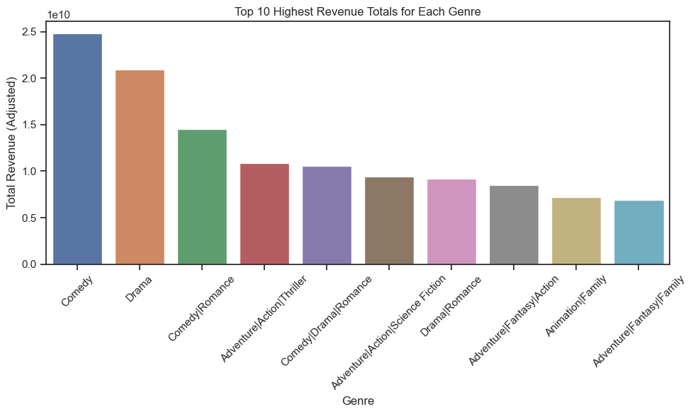

```
''
```

```python
#pd.options.display.float_format = '{:.2f}'.format
df3 = data[['genres', 'revenue_adj']].copy()

# Drop rows where "genres" is null
df3 = df3.dropna(subset=["genres"])

# Create dummy variables for genres
movie_genres = df3['genres'].str.get_dummies(sep='|')

# Concatenate the dummy variables with the original DataFrame
df_with_movie_genres = pd.concat([df3, movie_genres], axis=1)
df_with_movie_genres.head()
high_rev_genres = df_with_movie_genres.drop(columns=['genres'], axis=1)
# Calculate total revenue_adj for each genre
genre_revenue_totals = df_with_movie_genres.groupby('genres')['revenue_adj'].sum()

# Select the top 10 highest revenue totals for each column
top_10_revenue_totals = genre_revenue_totals.nlargest(10)

# Plotting
plt.figure(figsize=(10, 6))
sns.barplot(x=top_10_revenue_totals.index, y=top_10_revenue_totals.values)
plt.title('Top 10 Highest Revenue Totals for Each Genre')
plt.xlabel('Genre')
plt.ylabel('Total Revenue (Adjusted)')
plt.xticks(rotation=45)
plt.tight_layout()
plt.show()
;
```

**While not the “Most” profitable, Drama is one of the biggest revenue drivers.**

**Below shows the most profitable films with their genres**

```python
top_10_films_with_genre = df.nlargest(10, 'revenue_adj')
top_10_films_with_genre[['original_title','genres','budget_adj']]
```

|  | original_title | genres | budget_adj |
| --- | --- | --- | --- |
| 10853 | Avatar | Action\|Adventure\|Fantasy\|Science Fiction | 240886902.90 |
| 9228 | Star Wars | Adventure\|Action\|Science Fiction | 39575591.36 |
| 10861 | Titanic | Drama\|Romance\|Thriller | 271692064.20 |
| 9224 | The Exorcist | Drama\|Horror\|Thriller | 39289276.63 |
| 8651 | Jaws | Horror\|Thriller\|Adventure | 28362748.20 |
| 10802 | Star Wars: The Force Awakens | Action\|Adventure\|Science Fiction\|Fantasy | 183999919.00 |
| 8345 | E.T. the Extra-Terrestrial | Science Fiction\|Adventure\|Family\|Fantasy | 23726245.23 |
| 8705 | One Hundred and One Dalmatians | Adventure\|Animation\|Comedy\|Family | 29179444.83 |
| 10833 | The Avengers | Science Fiction\|Action\|Adventure | 208943741.90 |
| 9499 | The Empire Strikes Back | Adventure\|Action\|Science Fiction | 47628661.55 |

## Conclusions

So, what makes a “Good film”? I knew that this would be a nigh on impossible question to answer. Film, like any other art form, is truly subjective. As film studios are, first and foremost, businesses. Films can cost millions of dollars to produce and market, and It’s difficult to ascertain what the exact key factors are that make a “Good” film.

There a many variables that impact a films box office, popularity etc. How are films being marketed over the years? What was in the cultural zeitgeist at the time?

A big budget film doesn’t guarantee huge returns. “Movie stars” don’t always generate box office dollars. We’ve seen that films that don’t have a high vote average and/or are highly popular can generate huge returns, quite the opposite can actually happen.

Ask yourself this, would you class Avatar and the original Star Wars film as “Action | Adventure | Fantasy | Science Fiction”? Well only Avatar is described as such, while Star Wars is described as “Adventure | Action | Science Fiction”. Again, subjective.

The dataset, while rich, would benefit from having some useful information such as critics scores from “Rotten Tomatoes”, award information and the exit poll data from “Cinemascore”

All in all, there is no perfect formula to make a good film, but studios have a better chance of making money if they observe some of the more useful factors, genres and actors. But it is still no guarantee.